# Modeling Plant Establishment from Ornithochory

David S, Mason

4/15/2021

## Overview

**HO: The number of plants establishing via ornithochory is the same in recent burns and 1 year rough.**

**HA: The number of plants establishing via ornithochory is different in recent burns than 1 year rough.**

Below is a series of models using seed rain and plant establishment data in conjunction to predict the number of plants establishing from bird-mediated rain at recent burns and 1 year rough. *This model does not include density-dependent effects, which are known to influence plant population dynamics.*

First, I predict mean seed arrival per m^2 (below a perch). Next, I simulate plant establishment trials (these are not completed). Then, I use the seed arrival estimate as the number of trials in a binomial distribution, with the probability of success estimated from the simulated data. Finally, I bootstrap the likelihoods under the null and alternative hypotheses to assess whether a model incorporating the treatment (time since fire) better predicts plant establishment than a null model.

## Set-up the workspace

```r
require(tidyverse)

# Load in the data to filter data
seeds <- read.csv("seed_trap.csv", header = T) # Bring in the data

# Convert the site x species matrix into the long format
seeds_long <- pivot_longer(seeds, cols = 4:9,names_to = "SPECIES",
                                                     values_to = "SEEDS")

# Filter the data by treatment (control is 1 year rough)
burn <- seeds_long %>%
filter(TREATMENT == "BURN")
control <- seeds_long %>%
filter(TREATMENT == "CONTROL")
```

## Calculate seed arrival MLE

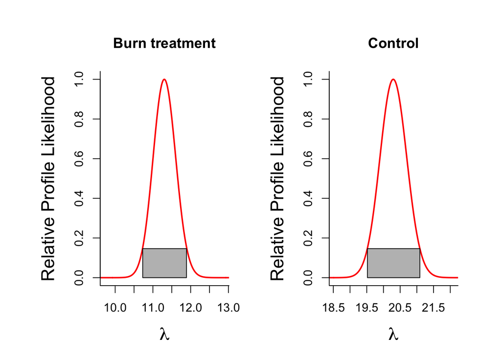

```r
treatment <- function(burn,control ,plot.it=TRUE){

    # Computing Likelihood for Observed Data ####
    llh_poisson <- function(lambda, y){
        # log(likelihood) by summing
        llh <- sum(dpois(y, lambda, log=TRUE))
        return(llh)
    }

    lambdas <- seq(0,100, by=0.01)

    # compute log-likelihood for all lambda values
    burn_ll <- sapply(lambdas,function(x){llh_poisson(x,burn$SEEDS)})
    max.burn.ll <- max(burn_ll)
    burn.mle <- lambdas[burn_ll==max.burn.ll]
    burn.rel.l <- exp(burn_ll - max.burn.ll)
    burn.ci.cuttoff <- exp(-qchisq(p=0.95, df=1)/2)
    burn.cut.m.rell <- burn.ci.cuttoff - burn.rel.l
    burn.ci.indices <- which(burn.cut.m.rell<0, arr.ind=TRUE)
    burn.len.ciind <- length(burn.ci.indices)
    burn.left.CL <- lambdas[burn.ci.indices[1]]
    burn.right.CL <-lambdas[burn.ci.indices[burn.len.ciind]]
    n.burn <- length(burn$SEEDS)

    control_ll <- sapply(lambdas,function(x){llh_poisson(x,control$SEEDS)})
    max.control.ll <- max(control_ll)
    control.mle <- lambdas[control_ll==max.control.ll]
    control.rel.l <- exp(control_ll - max.control.ll)
    control.ci.cuttoff <- exp(-qchisq(p=0.95, df=1)/2)
    control.cut.m.rell <- control.ci.cuttoff - control.rel.l
    control.ci.indices <- which(control.cut.m.rell<0, arr.ind=TRUE)
    control.len.ciind <- length(control.ci.indices)
    control.left.CL <- lambdas[control.ci.indices[1]]
    control.right.CL <-lambdas[control.ci.indices[control.len.ciind]]
    n.control <- length(control$SEEDS)

    #### Null model log-likelihood: no difference between burn and control?
    all.data  <- c(as.vector(burn$SEEDS), as.vector(control$SEEDS))
    null_ll <- sapply(lambdas,function(x){llh_poisson(x,all.data)})
    max.null.ll <- max(null_ll)
    null.mle <- lambdas[null_ll==max.null.ll]

    bic.sep.model <- -2*(max.burn.ll+max.control.ll) + 2*log(n.burn+n.control)
    bic.null.model <- -2*max.null.ll + 1*log(n.burn+n.control)
    if(bic.sep.model<bic.null.model){outcome <-
        "Separate model is best"}else{outcome<-
            "There's no difference between control and burn"}
    # Save the lambdas and log-likelihoods in a data frame
    burn_df <- data.frame(ll=burn_ll, lambda=lambdas)
    burn_df$TREATMENT <- c("BURN")
    control_df <- data.frame(ll=control_ll, lambda=lambdas)
    control_df$TREATMENT <- c("CONTROL")
    profile.ll <- rbind(burn_df, control_df)

    # Save the MLES and the confidence intervals
    burn.cis <- c(burn.left.CL, burn.mle, burn.right.CL)
    ctl.cis  <- c(control.left.CL, control.mle, control.right.CL)
    out <- rbind(burn.cis, ctl.cis)
    colnames(out) <- c("LCL", "MLE", "UPL")
    rownames(out) <- c("Burn treat.", "Control")



    if(plot.it==TRUE){

        burn.ci <- seq(from=burn.left.CL, to=burn.right.CL, by=0.01)
        ctl.ci <- seq(from=control.left.CL, to=control.right.CL, by=0.01)
        ci.height <- burn.ci.cuttoff

        xlims.burn <- c(burn.left.CL-1, burn.right.CL+1)
        xlims.ctl  <- c(control.left.CL-1, control.right.CL+1)
        par(mfrow=c(1,2), oma=c(1,2,1,1), mar=c(4,5,4,2))
        plot(lambdas, burn.rel.l, type="l", col="red", lwd=2, xlim=xlims.burn, xlab=expression(lambda),
        ylab="Relative Profile Likelihood", cex.lab=1.5, bty="l", main="Burn treatment")
        polygon(x=c(burn.ci,rev(burn.ci)), y=c(rep(0,length(burn.ci)),rep(ci.height,length(burn.ci))), col="grey")
        plot(lambdas, control.rel.l, type="l", col="red", lwd=2, xlim=xlims.ctl,xlab=expression(lambda),
        ylab="Relative Profile Likelihood", cex.lab=1.5, bty="l", main="Control")
        polygon(x=c(ctl.ci,rev(ctl.ci)), y=c(rep(0,length(ctl.ci)),rep(ci.height,length(ctl.ci))), col="grey")

    }


    return(list(CIS.lambdas=out,bic.sep.model=bic.sep.model, bic.null.model=bic.null.model, outcome=outcome))
}
```

```r
# Extract the MLEs
out.mle <- output[[1]]

# Separate the burn from control MLEs
burn.lamb.mle <- out.mle[1,3]
control.lamb.mle <- out.mle[2,3]
```

## Simulate plant establishment data

```r
# Number of trials
N <- 10
burn.reps <- 21
control.reps <- 21

# Simulate the data
burn.samp <- rbinom(n=burn.reps, size=N, prob=0.40)
cont.samp <- rbinom(n=burn.reps, size=N, prob=0.16)

# Calculate phat
burn.p.hat <- sum(burn.samp)/(N*length(burn.samp))
cont.p.hat <- sum(cont.samp)/(N*length(cont.samp))
```

## Predict seed establishment for treatments

```r
# Simulate data using probability from simulated data
# and the number of trials from the estimation of seed arrival
burn.est <- rbinom(n=burn.reps, size=round(burn.lamb.mle), prob = burn.p.hat)
cont.est <- rbinom(n=control.reps, size=round(control.lamb.mle), prob = cont.p.hat)
```

## Compare predicted seed establishment between treatments

```r
# Comparing total plant establishmet by treatment
lnLo <- function(burn,control,Ntrials){

    both.counts <- c(burn,control)
    p.hat <- sum(both.counts)/(Ntrials*length(both.counts))
    llikevec <- dbinom(x=both.counts, size=Ntrials, prob=p.hat, log=TRUE)
    return(sum(llikevec))
}

# Likelihood function under the alternative
lnL1 <- function(burn,control,Ntrials){

    phat.burn <- sum(burn)/(Ntrials*length(burn))
    phat.cont <- sum(control)/(Ntrials*length(control))

    llike.burn <- sum(dbinom(x=burn,size=Ntrials, prob=phat.burn, log=TRUE))
    llike.cont <- sum(dbinom(x=control,size=Ntrials, prob=phat.cont, log=TRUE))

    return(sum(c(llike.burn,llike.cont)))
}

# Computing Gsq = -2log(Lo/L1)
lnLo.hat <- lnLo(burn=burn.est, control=cont.est, Ntrials=N)
lnL1.hat <- lnL1(burn=burn.est, control=cont.est, Ntrials=N)

Gsq <- -2*(lnLo.hat-lnL1.hat)
alpha <- 0.001
Gsq.crit <- qchisq(p=1-alpha, df=3-1)
pvalue <- 1-pchisq(q=Gsq, df=3-1)

# Parametric bootstrapping
boot <- 5000
both <- c(burn.est,cont.est)
phat.Ho <- sum(both)/(N*length(both)); # MLE under H0 = sum(xis)/sum(nis)
Gsq.vec <- rep(0,boot)

for(i in 1:boot){
    # Simulate data like the one observed but under the Null hypothesis

    burn.boot <- rbinom(n=burn, size=N, prob=phat.Ho)
    cont.boot <- rbinom(n=control, size=N, prob=phat.Ho)

    lnLo.boot <- lnLo(burn=burn.boot, control=cont.boot, Ntrials=N)
    lnL1.boot <- lnL1(burn=burn.boot, control=cont.boot, Ntrials=N)

    Gsq.vec[i] <- -2*(lnLo.boot-lnL1.boot)

}

boot.pval <- sum(Gsq.vec > Gsq)/2000 # Proportion of boostrap Gsq's that are bigger than the observed Gsq
print(boot.pval) # compare to Chisquare pvalue
```

```
## [1] 0
```

```r
print(pvalue)
```

```
## [1] 1.45686e-05
```

[figure not shown]